# Experiment 1 Notes

# 1 Background (the project)

This project seeks to investigate the processing of islands: in particular, those that we have reason to believe are more tolerant of island-violating extraction: specifically, islands that are embedded in non-presupposed, indefinite DPs. To illustrate the phenomenon, observe that the only difference between the following island-violating sentences is that in the first, the CP complement to N (henceforth, N-CP) island is embedded in a DP headed by the indefinite determiner ‘a’, while in the second example, the same island is embedded in a definite DP (headed by ‘the’).

1. 1. ?Mary is the woman [who I heard a rumor [Amherst wants to hire __ ]].
   2. *Mary is the woman [who I heard the rumor [Amherst wants to hire __ ]].

Informal surveys of native English speakers suggest that the first example (with the indefinite determiner) is more acceptable than the second example (with the definite determiner). Clearly, broad claims about acceptability patterns should be experimentally verified (especially in cases like this, in which the claim is about sentences that are already degraded), which is one of the goals of this project. But there are a couple reasons why the purported pattern is worth investigating more systematically. First of all, a number of studies have claimed that the pattern above holds for languages other than English. Sichel (2018) argues that extraction out of RCs in indefinite DPs is systematically acceptable, in contrast to the same extraction from definite DPs, and Lindahl (2015) shows that the same holds for Swedish. In fact, the pattern has been reported for quite a handful of languages (see references cited in Sichel (2018, 3)).

2. 1. Isn’t she the woman [who I’ve heard **a rumor** [Amherst wants to hire __ ]]? (1983, (3b))
   2. That’s one trick [that I’ve known **a lot of people** [who have been taken in by __ ]]. (1983, (4d))
   3. This is a paper [that we really need to find **someone** [who understands __ ]]. (1983, (9c))
   4. Then you look at what happens in languages that you know and languages [that you have **a friend** [who knows __ ]]. (1983, (10a))
   5. Violence is something [that there are **many Americans** [who condone __ ]]. (1983, (10c))
   6. This is the child [who there is **nobody** [who is willing to accept __ ]]. (1983, (10d))
   7. Tony, let me ask you about a rumor [that I’ve never been able to find **anybody** [who could confirm __ ]]. (1983, (11a))
   8. This is the highway [that I actually know **somebody** [who has had an accident on __ ]]. (1983, (11b))

Of their examples of extraction from islands in DPs, only two involve extraction from a *definite* DP, and both of these involve the use of ‘only’, instead of just the definite determiner by itself.

3. 1. Isn’t that the song [that Paul and Stevie were **the only ones** [who wanted to record __ ]]? (1983, (9b))
   2. This is the one [that Bob Wall was **the only person** [who hadn’t read __ ]]. (1983, (10b))

All this is to say that this is a worthy topic of investigation—there may be something to find here. And at this point, a number of questions come up. If there is an effect of the definiteness of the island-embedding DP, is the effect inherent to definiteness, or is the definiteness effect contingent on something else? Sichel (2018) claims that the effect in Hebrew is not intrinsic to indefiniteness, but that indefinite DPs do not move from their base position, and so there are no freezing effects that would render the DP’s contents invisible to a probe. (This is in contrast to definite DPs, which she claims often move from their base position because of information-structural properties of definite DPs, resulting in a freezing effect that prevents extraction from the moved definite DP.) In addition, she argues that the RC must be derived by raising, instead of matching, because this results in a structure that is transparent to extraction (due to its lack of an NP layer, which she claims constitutes a phase).

4. 1. **Raising RC (transparent to extraction):** [<sub>DP</sub> [<sub>D</sub> ] [<sub>CP</sub> … ]]
   2. **Matching RC (opaque to extraction):** [<sub>DP</sub> [<sub>D</sub> ] [<sub>NP</sub> [<sub>N</sub> ] [<sub>CP</sub> … ]]]

On the other hand, Lindahl (2015) doesn’t mention definiteness at all, but proposes that extraction from RCs can occur as long as the extracted argument has a discourse-related feature that allows it to become a second specifier of the relative clause complementizer.

# 2 Experiment 1

## 2.1 Items

### 2.1.1 Factors

1. Definiteness of the embedding DP (definite, indefinite)
2. Dependency length (short, long)
3. Embedded clause type (island, non-island)

### 2.1.2 Sample item sets

#### 2.1.2.1 Island type: RC

1. Who appreciated that the students finished the optional assignment? (Non-island, Short dependency, Definite)
2. Who appreciated that students finished the optional assignment? (Non-island, Short dependency, Indefinite)
3. What did Patty appreciate that the students finished? (Non-island, Long dependency, Definite)
4. What did Patty appreciate that students finished? (Non-Island, Long dependency, Indefinite)
5. Who appreciated the students who finished the optional assignment? (Island, Short dependency, Definite)
6. Who appreciated students who finished the optional assignment? (Island, Short dependency, Indefinite)
7. What did Patty appreciate the students who finished? (Island, Long dependency, Definite)
8. What did Patty appreciate students who finished? (Island, Long dependency, Indefinite)

#### 2.1.2.2 Island type: CP complement to N

1. Who claimed that the university wants to hire Stanley? (Non-island, Short dependency, Definite)
2. Who claimed that a university wants to hire Stanley? (Non-island, Short dependency, Indefinite)
3. Who did Salazar claim that the university wants to hire? (Non-island, Long dependency, Definite)
4. Who did Salazar claim that a university wants to hire? (Non-Island, Long dependency, Indefinite)
5. Who heard the claim that the university wants to hire Stanley? (Island, Short dependency, Definite)
6. Who heard a claim that the university wants to hire Stanley? (Island, Short dependency, Indefinite)
7. Who did Salazar hear the claim that the university wants to hire? (Island, Long dependency, Definite)
8. Who did Salazar hear a claim that the university wants to hire? (Island, Long dependency, Indefinite)

## 2.2 Results

### 2.2.1 Data summary

The following table presents a summary of the ratings. Observe that the lowest-rated conditions are those with an island (ISL) and a dependency crossing an island boundary (LONG). This is the expected island effect. Another easily observable pattern is that the indefinite conditions are rated lower across the board compared to the corresponding definite condition.

| ec.type | dependency.length | definiteness | mean.rating | sd.rating | n | se.rating |
| --- | --- | --- | --- | --- | --- | --- |
| isl | long | def | 2.2 | 1.24 | 124 | 0.11 |
| isl | long | ind | 1.9 | 1.16 | 125 | 0.10 |
| isl | short | def | 4.7 | 1.47 | 123 | 0.13 |
| isl | short | ind | 4.3 | 1.56 | 124 | 0.14 |
| non.isl | long | def | 4.0 | 1.55 | 124 | 0.14 |
| non.isl | long | ind | 3.6 | 1.60 | 127 | 0.14 |
| non.isl | short | def | 5.1 | 1.24 | 125 | 0.11 |
| non.isl | short | ind | 4.7 | 1.31 | 124 | 0.12 |

| island.type | dependency.length | definiteness | mean.rating | sd.rating | n | se.rating |
| --- | --- | --- | --- | --- | --- | --- |
| N-CP | long | def | 2.5 | 1.30 | 61 | 0.17 |
| N-CP | long | ind | 2.3 | 1.26 | 62 | 0.16 |
| N-CP | short | def | 4.8 | 1.50 | 61 | 0.19 |
| N-CP | short | ind | 4.6 | 1.35 | 62 | 0.17 |
| RC | long | def | 2.0 | 1.14 | 63 | 0.14 |
| RC | long | ind | 1.6 | 0.94 | 63 | 0.12 |
| RC | short | def | 4.6 | 1.44 | 62 | 0.18 |
| RC | short | ind | 3.9 | 1.69 | 62 | 0.21 |

### 2.2.2 Data visualization

The following plot represents the overall ratings. The left side shows all the definite conditions, and when compared to the right side (indefinite conditions), one can see that the indefinite conditions are rated lower overall than the definite conditions; the ratings are shifted down but display the same general pattern.

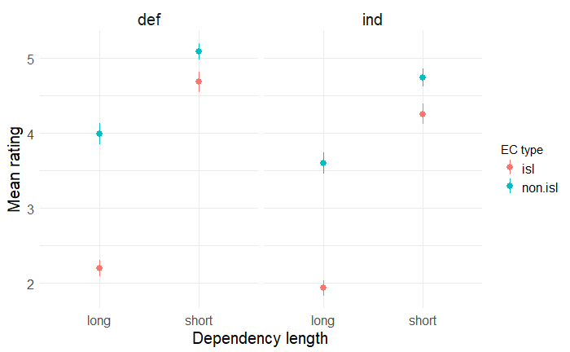

The following is a representation of the island conditions, comparing the ratings across the two island types.

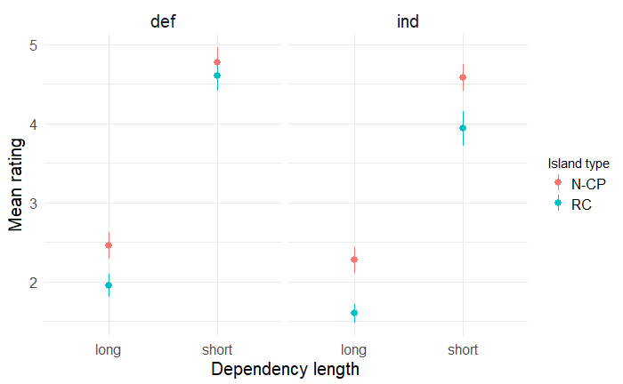

The two following plots are based on the subset of the data that has the RC item sets separated from the N-CP item sets, respectively.

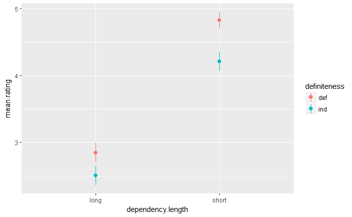

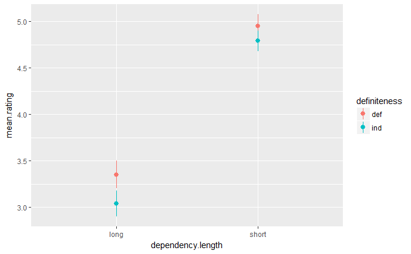

#### 2.2.2.1 Now looking only at islands…

[figure not shown]

```r
experiment_data %>% subset(ec.type=="isl") %>% droplevels %>% ggplot(aes(x = rating)) -> isl_ratings_plot

isl_ratings_plot + facet_grid(definiteness ~ dependency.length) +
  geom_histogram(bins=6)
```

### 2.2.3 Analysis

```
    [,1]
def -0.5
ind  0.5
        [,1]
isl      0.5
non.isl -0.5
      [,1]
long   0.5
short -0.5
```

#### 2.2.3.1 Cumulative link model analysis

```r
clm(rating ~ definiteness * ec.type * dependency.length, data = experiment_data) -> clm.def_ectype
summary(clm.def_ectype)
```

```
formula: rating ~ definiteness * ec.type * dependency.length
data:    experiment_data

 link  threshold nobs logLik   AIC     niter max.grad cond.H
 logit flexible  996  -1535.85 3095.71 5(0)  1.69e-12 1.5e+02

Coefficients:
                                           Estimate Std. Error z value Pr(>|z|)
definiteness1                             -0.485471   0.115190  -4.215 2.50e-05 ***
ec.type1                                  -1.331746   0.121241 -10.984  < 2e-16 ***
dependency.length1                        -2.153736   0.129317 -16.655  < 2e-16 ***
definiteness1:ec.type1                     0.005638   0.229327   0.025    0.980
definiteness1:dependency.length1           0.126322   0.229682   0.550    0.582
ec.type1:dependency.length1               -1.584530   0.238251  -6.651 2.92e-11 ***
definiteness1:ec.type1:dependency.length1  0.008292   0.458784   0.018    0.986
---
Signif. codes:  0 ‘***’ 0.001 ‘**’ 0.01 ‘*’ 0.05 ‘.’ 0.1 ‘ ’ 1

Threshold coefficients:
    Estimate Std. Error z value
1|2 -2.46784    0.11344 -21.755
2|3 -1.22807    0.08523 -14.409
3|4 -0.27012    0.07424  -3.638
4|5  0.54304    0.07367   7.371
5|6  1.48061    0.08265  17.915
```

**RCs only**

```r
## Make sure the ratings are a factor
experiment_data_RC$rating %<>% factor
### Reassign contrasts
contrasts(experiment_data_RC$definiteness) <- c(-0.5, 0.5)
contrasts(experiment_data_RC$ec.type) <- c(0.5, -0.5)
contrasts(experiment_data_RC$dependency.length) <- c(0.5, -0.5)
## Run CLM analysis
clm(rating ~ definiteness * ec.type * dependency.length, data = experiment_data_RC) -> clm.RC_only
summary(clm.RC_only)
```

```
formula: rating ~ definiteness * ec.type * dependency.length
data:    experiment_data_RC

 link  threshold nobs logLik  AIC     niter max.grad cond.H
 logit flexible  501  -764.04 1552.08 5(0)  1.13e-11 1.6e+02

Coefficients:
                                          Estimate Std. Error z value Pr(>|z|)
definiteness1                              -0.6238     0.1644  -3.795 0.000147 ***
ec.type1                                   -1.4637     0.1739  -8.416  < 2e-16 ***
dependency.length1                         -2.2490     0.1840 -12.220  < 2e-16 ***
definiteness1:ec.type1                     -0.1398     0.3262  -0.428 0.668317
definiteness1:dependency.length1            0.2163     0.3273   0.661 0.508692
ec.type1:dependency.length1                -1.7500     0.3405  -5.140 2.75e-07 ***
definiteness1:ec.type1:dependency.length1  -0.2387     0.6527  -0.366 0.714564
---
Signif. codes:  0 ‘***’ 0.001 ‘**’ 0.01 ‘*’ 0.05 ‘.’ 0.1 ‘ ’ 1

Threshold coefficients:
    Estimate Std. Error z value
1|2  -2.1545     0.1511 -14.262
2|3  -0.8638     0.1149  -7.519
3|4   0.1036     0.1048   0.989
4|5   0.8008     0.1073   7.462
5|6   1.6959     0.1223  13.869
```

**CP complements only**

```r
## Make sure ratings are a factor
experiment_data_NCP$rating %<>% factor
### Reassign contrasts
contrasts(experiment_data_NCP$definiteness) <- c(-0.5, 0.5)
contrasts(experiment_data_NCP$ec.type) <- c(0.5, -0.5)
contrasts(experiment_data_NCP$dependency.length) <- c(0.5, -0.5)
## Run CLM analysis
clm(rating ~ definiteness * ec.type * dependency.length, data = experiment_data_NCP) -> clm.NCP_only
summary(clm.NCP_only)
```

```
formula: rating ~ definiteness * ec.type * dependency.length
data:    experiment_data_NCP

 link  threshold nobs logLik  AIC     niter max.grad cond.H
 logit flexible  495  -753.29 1530.58 5(0)  4.56e-12 1.3e+02

Coefficients:
                                           Estimate Std. Error z value Pr(>|z|)
definiteness1                             -0.395887   0.163385  -2.423   0.0154 *
ec.type1                                  -1.272502   0.171495  -7.420 1.17e-13 ***
dependency.length1                        -2.146967   0.184684 -11.625  < 2e-16 ***
definiteness1:ec.type1                     0.125718   0.325523   0.386   0.6993
definiteness1:dependency.length1          -0.009231   0.325750  -0.028   0.9774
ec.type1:dependency.length1               -1.549850   0.337884  -4.587 4.50e-06 ***
definiteness1:ec.type1:dependency.length1  0.286920   0.651659   0.440   0.6597
---
Signif. codes:  0 ‘***’ 0.001 ‘**’ 0.01 ‘*’ 0.05 ‘.’ 0.1 ‘ ’ 1

Threshold coefficients:
    Estimate Std. Error z value
1|2  -2.9188     0.1801 -16.206
2|3  -1.6417     0.1316 -12.478
3|4  -0.6423     0.1092  -5.880
4|5   0.3234     0.1035   3.123
5|6   1.3185     0.1138  11.590
```

**Running the analysis on predicted grammaticality instead of EC type b/c predicted grammaticality corresponds perfectly with whether or not there’s extraction from an island**

```
formula: rating ~ definiteness * predicted * dependency.length
data:    experiment_data

 link  threshold nobs logLik   AIC     niter max.grad cond.H
 logit flexible  996  -1541.28 3102.56 5(0)  1.70e-12 1.1e+02

Coefficients: (2 not defined because of singularities)
                                             Estimate Std. Error z value Pr(>|z|)
definiteness1                               -0.476756   0.141483  -3.370 0.000752 ***
predicted1                                   2.115881   0.175241  12.074  < 2e-16 ***
dependency.length1                          -1.088865   0.142086  -7.663 1.81e-14 ***
definiteness1:predicted1                    -0.008427   0.321006  -0.026 0.979056
definiteness1:dependency.length1             0.111466   0.277032   0.402 0.687419
predicted1:dependency.length1                      NA         NA      NA       NA
definiteness1:predicted1:dependency.length1        NA         NA      NA       NA
---
Signif. codes:  0 ‘***’ 0.001 ‘**’ 0.01 ‘*’ 0.05 ‘.’ 0.1 ‘ ’ 1

Threshold coefficients:
    Estimate Std. Error z value
1|2 -1.93030    0.10715 -18.014
2|3 -0.69117    0.09042  -7.644
3|4  0.26289    0.08924   2.946
4|5  1.06713    0.09201  11.598
5|6  1.99447    0.10029  19.888
```

**Mixed effects model by subjects and by items**

```
Cumulative Link Mixed Model fitted with the Laplace approximation

formula: rating ~ definiteness * ec.type * dependency.length + (1 + definiteness *
    ec.type * dependency.length | subject) + (1 + definiteness *
    ec.type * dependency.length | item.set)
data:    experiment_data

 link  threshold nobs logLik   AIC     niter         max.grad cond.H
 logit flexible  996  -1393.48 2954.97 33952(166872) 5.21e-03 3.4e+04

Random effects:
 Groups   Name                                                  Variance Std.Dev. Corr
 item.set (Intercept)                                           1.7862   1.3365
          definitenessind                                       0.1050   0.3241    0.073
          ec.typenon.isl                                        2.0225   1.4221   -0.850 -0.504
          dependency.lengthshort                                2.8047   1.6747   -0.613 -0.228
          definitenessind:ec.typenon.isl                        0.3558   0.5965    0.552 -0.004
          definitenessind:dependency.lengthshort                0.4556   0.6750   -0.579 -0.480
          ec.typenon.isl:dependency.lengthshort                 0.4607   0.6788    0.816  0.413
          definitenessind:ec.typenon.isl:dependency.lengthshort 0.9804   0.9901    0.901  0.122
 subject  (Intercept)                                           0.5943   0.7709
          definitenessind                                       0.9241   0.9613    0.053
          ec.typenon.isl                                        3.0084   1.7345   -0.563  0.523
          dependency.lengthshort                                0.7174   0.8470    0.097 -0.357
          definitenessind:ec.typenon.isl                        2.0440   1.4297    0.292 -0.516
          definitenessind:dependency.lengthshort                1.1113   1.0542   -0.480 -0.240
          ec.typenon.isl:dependency.lengthshort                 1.9321   1.3900    0.104 -0.073
          definitenessind:ec.typenon.isl:dependency.lengthshort 2.5198   1.5874    0.232  0.067




  0.785
 -0.625 -0.478
  0.731  0.252 -0.770
 -0.852 -0.760  0.189 -0.325
 -0.898 -0.758  0.784 -0.692  0.692



```

[output cut: 11 more lines]

```
dependency.length1                         -3.2657     0.3306  -9.877  < 2e-16 ***
definiteness1:ec.type1                      0.1490     0.4126   0.361    0.718
definiteness1:dependency.length1            0.1955     0.3421   0.572    0.568
ec.type1:dependency.length1                -2.2987     0.4679  -4.913 8.97e-07 ***
definiteness1:ec.type1:dependency.length1  -0.1072     0.6335  -0.169    0.866
---
Signif. codes:  0 ‘***’ 0.001 ‘**’ 0.01 ‘*’ 0.05 ‘.’ 0.1 ‘ ’ 1

Threshold coefficients:
    Estimate Std. Error z value
1|2  -3.5965     0.2744 -13.108
2|3  -1.8514     0.2482  -7.459
3|4  -0.4478     0.2391  -1.873
4|5   0.7636     0.2386   3.200
5|6   2.1879     0.2480   8.824
```

# 3 References

Chung, Sandra, and James McCloskey. 1983. “On the Interpretation of Certain Island Facts in GPSG.” *Linguistic Inquiry* 14 (4): 704–13. http://www.jstor.org/stable/4178357.

Lindahl, Filippa. 2015. “Swedish Relative Clauses as Weak Islands.” *LSA Annual Meeting Extended Abstracts* 6: 13—–1–5. doi:10.3765/exabs.v0i0.3000.

Sichel, Ivy. 2018. “Anatomy of a Counterexample: Extraction from relative clauses.” *Linguistic Inquiry* 49 (2).